# Risk Factor Analysis

## Outcome Variable

**Outcome Variable:** swasted

## Predictor Variables

**Intervention Variable:** enwast

**Adjustment Set:**

unadjusted

## Stratifying Variables

The analysis was stratified on these variable(s):

- agecat
- studyid
- country

## Data Summary

| agecat | studyid | country | enwast | swasted | n_cell | n |
| --- | --- | --- | --- | --- | --- | --- |
| Birth | ki0047075b-MAL-ED | BANGLADESH | 0 | 0 | 201 | 241 |
| Birth | ki0047075b-MAL-ED | BANGLADESH | 0 | 1 | 0 | 241 |
| Birth | ki0047075b-MAL-ED | BANGLADESH | 1 | 0 | 32 | 241 |
| Birth | ki0047075b-MAL-ED | BANGLADESH | 1 | 1 | 8 | 241 |
| Birth | ki0047075b-MAL-ED | BRAZIL | 0 | 0 | 177 | 183 |
| Birth | ki0047075b-MAL-ED | BRAZIL | 0 | 1 | 0 | 183 |
| Birth | ki0047075b-MAL-ED | BRAZIL | 1 | 0 | 6 | 183 |
| Birth | ki0047075b-MAL-ED | BRAZIL | 1 | 1 | 0 | 183 |
| Birth | ki0047075b-MAL-ED | INDIA | 0 | 0 | 170 | 203 |
| Birth | ki0047075b-MAL-ED | INDIA | 0 | 1 | 0 | 203 |
| Birth | ki0047075b-MAL-ED | INDIA | 1 | 0 | 26 | 203 |
| Birth | ki0047075b-MAL-ED | INDIA | 1 | 1 | 7 | 203 |
| Birth | ki0047075b-MAL-ED | NEPAL | 0 | 0 | 148 | 168 |
| Birth | ki0047075b-MAL-ED | NEPAL | 0 | 1 | 0 | 168 |
| Birth | ki0047075b-MAL-ED | NEPAL | 1 | 0 | 16 | 168 |
| Birth | ki0047075b-MAL-ED | NEPAL | 1 | 1 | 4 | 168 |
| Birth | ki0047075b-MAL-ED | PERU | 0 | 0 | 273 | 279 |
| Birth | ki0047075b-MAL-ED | PERU | 0 | 1 | 0 | 279 |
| Birth | ki0047075b-MAL-ED | PERU | 1 | 0 | 6 | 279 |
| Birth | ki0047075b-MAL-ED | PERU | 1 | 1 | 0 | 279 |
| Birth | ki0047075b-MAL-ED | SOUTH AFRICA | 0 | 0 | 240 | 258 |
| Birth | ki0047075b-MAL-ED | SOUTH AFRICA | 0 | 1 | 0 | 258 |
| Birth | ki0047075b-MAL-ED | SOUTH AFRICA | 1 | 0 | 16 | 258 |
| Birth | ki0047075b-MAL-ED | SOUTH AFRICA | 1 | 1 | 2 | 258 |
| Birth | ki0047075b-MAL-ED | TANZANIA, UNITED REPUBLIC OF | 0 | 0 | 116 | 118 |
| Birth | ki0047075b-MAL-ED | TANZANIA, UNITED REPUBLIC OF | 0 | 1 | 0 | 118 |
| Birth | ki0047075b-MAL-ED | TANZANIA, UNITED REPUBLIC OF | 1 | 0 | 1 | 118 |
| Birth | ki0047075b-MAL-ED | TANZANIA, UNITED REPUBLIC OF | 1 | 1 | 1 | 118 |
| Birth | ki1000108-CMC-V-BCS-2002 | INDIA | 0 | 0 | 74 | 88 |
| Birth | ki1000108-CMC-V-BCS-2002 | INDIA | 0 | 1 | 0 | 88 |

[output cut: 314 more lines]

The following strata were considered:

- agecat: 24 months, studyid: ki0047075b-MAL-ED, country: BANGLADESH
- agecat: 24 months, studyid: ki0047075b-MAL-ED, country: BRAZIL
- agecat: 24 months, studyid: ki0047075b-MAL-ED, country: INDIA
- agecat: 24 months, studyid: ki0047075b-MAL-ED, country: NEPAL
- agecat: 24 months, studyid: ki0047075b-MAL-ED, country: PERU
- agecat: 24 months, studyid: ki0047075b-MAL-ED, country: SOUTH AFRICA
- agecat: 24 months, studyid: ki0047075b-MAL-ED, country: TANZANIA, UNITED REPUBLIC OF
- agecat: 24 months, studyid: ki1000108-CMC-V-BCS-2002, country: INDIA
- agecat: 24 months, studyid: ki1000108-IRC, country: INDIA
- agecat: 24 months, studyid: ki1017093-NIH-Birth, country: BANGLADESH
- agecat: 24 months, studyid: ki1017093b-PROVIDE, country: BANGLADESH
- agecat: 24 months, studyid: ki1017093c-NIH-Crypto, country: BANGLADESH
- agecat: 24 months, studyid: ki1066203-TanzaniaChild2, country: TANZANIA, UNITED REPUBLIC OF
- agecat: 24 months, studyid: ki1101329-Keneba, country: GAMBIA
- agecat: 24 months, studyid: ki1113344-GMS-Nepal, country: NEPAL
- agecat: 24 months, studyid: ki1114097-CMIN, country: BANGLADESH
- agecat: 24 months, studyid: ki1114097-CMIN, country: GUINEA-BISSAU
- agecat: 24 months, studyid: ki1114097-CMIN, country: PERU
- agecat: 24 months, studyid: ki1114097-CONTENT, country: PERU
- agecat: 24 months, studyid: ki1119695-PROBIT, country: BELARUS
- agecat: 24 months, studyid: ki1126311-ZVITAMBO, country: ZIMBABWE
- agecat: 24 months, studyid: ki1135781-COHORTS, country: GUATEMALA
- agecat: 24 months, studyid: ki1135781-COHORTS, country: INDIA
- agecat: 24 months, studyid: ki1135781-COHORTS, country: PHILIPPINES
- agecat: 24 months, studyid: ki1148112-LCNI-5, country: MALAWI
- agecat: 24 months, studyid: kiGH5241-JiVitA-3, country: BANGLADESH
- agecat: 24 months, studyid: kiGH5241-JiVitA-4, country: BANGLADESH
- agecat: 6 months, studyid: ki0047075b-MAL-ED, country: BANGLADESH
- agecat: 6 months, studyid: ki0047075b-MAL-ED, country: BRAZIL
- agecat: 6 months, studyid: ki0047075b-MAL-ED, country: INDIA
- agecat: 6 months, studyid: ki0047075b-MAL-ED, country: NEPAL
- agecat: 6 months, studyid: ki0047075b-MAL-ED, country: PERU
- agecat: 6 months, studyid: ki0047075b-MAL-ED, country: SOUTH AFRICA
- agecat: 6 months, studyid: ki0047075b-MAL-ED, country: TANZANIA, UNITED REPUBLIC OF
- agecat: 6 months, studyid: ki1000108-CMC-V-BCS-2002, country: INDIA
- agecat: 6 months, studyid: ki1000108-IRC, country: INDIA
- agecat: 6 months, studyid: ki1000109-EE, country: PAKISTAN
- agecat: 6 months, studyid: ki1000109-ResPak, country: PAKISTAN
- agecat: 6 months, studyid: ki1000304b-SAS-CompFeed, country: INDIA
- agecat: 6 months, studyid: ki1000304b-SAS-FoodSuppl, country: INDIA
- agecat: 6 months, studyid: ki1017093-NIH-Birth, country: BANGLADESH
- agecat: 6 months, studyid: ki1017093b-PROVIDE, country: BANGLADESH
- agecat: 6 months, studyid: ki1017093c-NIH-Crypto, country: BANGLADESH
- agecat: 6 months, studyid: ki1066203-TanzaniaChild2, country: TANZANIA, UNITED REPUBLIC OF
- agecat: 6 months, studyid: ki1101329-Keneba, country: GAMBIA
- agecat: 6 months, studyid: ki1112895-Guatemala BSC, country: GUATEMALA
- agecat: 6 months, studyid: ki1113344-GMS-Nepal, country: NEPAL
- agecat: 6 months, studyid: ki1114097-CMIN, country: BANGLADESH
- agecat: 6 months, studyid: ki1114097-CMIN, country: BRAZIL
- agecat: 6 months, studyid: ki1114097-CMIN, country: GUINEA-BISSAU
- agecat: 6 months, studyid: ki1114097-CMIN, country: PERU
- agecat: 6 months, studyid: ki1114097-CONTENT, country: PERU
- agecat: 6 months, studyid: ki1119695-PROBIT, country: BELARUS
- agecat: 6 months, studyid: ki1126311-ZVITAMBO, country: ZIMBABWE
- agecat: 6 months, studyid: ki1135781-COHORTS, country: GUATEMALA
- agecat: 6 months, studyid: ki1135781-COHORTS, country: INDIA
- agecat: 6 months, studyid: ki1135781-COHORTS, country: PHILIPPINES
- agecat: 6 months, studyid: ki1148112-LCNI-5, country: MALAWI
- agecat: 6 months, studyid: kiGH5241-JiVitA-3, country: BANGLADESH
- agecat: 6 months, studyid: kiGH5241-JiVitA-4, country: BANGLADESH
- agecat: Birth, studyid: ki0047075b-MAL-ED, country: BANGLADESH
- agecat: Birth, studyid: ki0047075b-MAL-ED, country: BRAZIL
- agecat: Birth, studyid: ki0047075b-MAL-ED, country: INDIA
- agecat: Birth, studyid: ki0047075b-MAL-ED, country: NEPAL
- agecat: Birth, studyid: ki0047075b-MAL-ED, country: PERU
- agecat: Birth, studyid: ki0047075b-MAL-ED, country: SOUTH AFRICA
- agecat: Birth, studyid: ki0047075b-MAL-ED, country: TANZANIA, UNITED REPUBLIC OF
- agecat: Birth, studyid: ki1000108-CMC-V-BCS-2002, country: INDIA
- agecat: Birth, studyid: ki1000108-IRC, country: INDIA
- agecat: Birth, studyid: ki1000109-EE, country: PAKISTAN
- agecat: Birth, studyid: ki1000109-ResPak, country: PAKISTAN
- agecat: Birth, studyid: ki1000304b-SAS-CompFeed, country: INDIA
- agecat: Birth, studyid: ki1017093-NIH-Birth, country: BANGLADESH
- agecat: Birth, studyid: ki1017093c-NIH-Crypto, country: BANGLADESH
- agecat: Birth, studyid: ki1101329-Keneba, country: GAMBIA
- agecat: Birth, studyid: ki1114097-CMIN, country: BANGLADESH
- agecat: Birth, studyid: ki1114097-CMIN, country: BRAZIL
- agecat: Birth, studyid: ki1114097-CMIN, country: PERU
- agecat: Birth, studyid: ki1114097-CONTENT, country: PERU
- agecat: Birth, studyid: ki1119695-PROBIT, country: BELARUS
- agecat: Birth, studyid: ki1126311-ZVITAMBO, country: ZIMBABWE
- agecat: Birth, studyid: ki1135781-COHORTS, country: GUATEMALA
- agecat: Birth, studyid: ki1135781-COHORTS, country: INDIA
- agecat: Birth, studyid: ki1135781-COHORTS, country: PHILIPPINES
- agecat: Birth, studyid: kiGH5241-JiVitA-3, country: BANGLADESH
- agecat: Birth, studyid: kiGH5241-JiVitA-4, country: BANGLADESH

### Dropped Strata

Some strata were dropped due to rare outcomes:

- agecat: Birth, studyid: ki0047075b-MAL-ED, country: BANGLADESH
- agecat: Birth, studyid: ki0047075b-MAL-ED, country: BRAZIL
- agecat: Birth, studyid: ki0047075b-MAL-ED, country: INDIA
- agecat: Birth, studyid: ki0047075b-MAL-ED, country: NEPAL
- agecat: Birth, studyid: ki0047075b-MAL-ED, country: PERU
- agecat: Birth, studyid: ki0047075b-MAL-ED, country: SOUTH AFRICA
- agecat: Birth, studyid: ki0047075b-MAL-ED, country: TANZANIA, UNITED REPUBLIC OF
- agecat: Birth, studyid: ki1000108-CMC-V-BCS-2002, country: INDIA
- agecat: Birth, studyid: ki1000108-IRC, country: INDIA
- agecat: Birth, studyid: ki1000109-EE, country: PAKISTAN
- agecat: Birth, studyid: ki1000109-ResPak, country: PAKISTAN
- agecat: Birth, studyid: ki1000304b-SAS-CompFeed, country: INDIA
- agecat: Birth, studyid: ki1017093-NIH-Birth, country: BANGLADESH
- agecat: Birth, studyid: ki1017093c-NIH-Crypto, country: BANGLADESH
- agecat: Birth, studyid: ki1101329-Keneba, country: GAMBIA
- agecat: Birth, studyid: ki1114097-CMIN, country: BANGLADESH
- agecat: Birth, studyid: ki1114097-CMIN, country: BRAZIL
- agecat: Birth, studyid: ki1114097-CMIN, country: PERU
- agecat: Birth, studyid: ki1114097-CONTENT, country: PERU
- agecat: Birth, studyid: ki1119695-PROBIT, country: BELARUS
- agecat: Birth, studyid: ki1126311-ZVITAMBO, country: ZIMBABWE
- agecat: Birth, studyid: ki1135781-COHORTS, country: GUATEMALA
- agecat: Birth, studyid: ki1135781-COHORTS, country: INDIA
- agecat: Birth, studyid: ki1135781-COHORTS, country: PHILIPPINES
- agecat: Birth, studyid: kiGH5241-JiVitA-3, country: BANGLADESH
- agecat: Birth, studyid: kiGH5241-JiVitA-4, country: BANGLADESH
- agecat: 6 months, studyid: ki0047075b-MAL-ED, country: BANGLADESH
- agecat: 6 months, studyid: ki0047075b-MAL-ED, country: BRAZIL
- agecat: 6 months, studyid: ki0047075b-MAL-ED, country: INDIA
- agecat: 6 months, studyid: ki0047075b-MAL-ED, country: NEPAL
- agecat: 6 months, studyid: ki0047075b-MAL-ED, country: PERU
- agecat: 6 months, studyid: ki0047075b-MAL-ED, country: SOUTH AFRICA
- agecat: 6 months, studyid: ki0047075b-MAL-ED, country: TANZANIA, UNITED REPUBLIC OF
- agecat: 6 months, studyid: ki1000108-CMC-V-BCS-2002, country: INDIA
- agecat: 6 months, studyid: ki1000109-ResPak, country: PAKISTAN
- agecat: 6 months, studyid: ki1017093-NIH-Birth, country: BANGLADESH
- agecat: 6 months, studyid: ki1017093b-PROVIDE, country: BANGLADESH
- agecat: 6 months, studyid: ki1017093c-NIH-Crypto, country: BANGLADESH
- agecat: 6 months, studyid: ki1101329-Keneba, country: GAMBIA
- agecat: 6 months, studyid: ki1112895-Guatemala BSC, country: GUATEMALA
- agecat: 6 months, studyid: ki1114097-CMIN, country: BANGLADESH
- agecat: 6 months, studyid: ki1114097-CMIN, country: BRAZIL
- agecat: 6 months, studyid: ki1114097-CMIN, country: GUINEA-BISSAU
- agecat: 6 months, studyid: ki1114097-CMIN, country: PERU
- agecat: 6 months, studyid: ki1114097-CONTENT, country: PERU
- agecat: 6 months, studyid: ki1135781-COHORTS, country: GUATEMALA
- agecat: 6 months, studyid: ki1148112-LCNI-5, country: MALAWI
- agecat: 24 months, studyid: ki0047075b-MAL-ED, country: BANGLADESH
- agecat: 24 months, studyid: ki0047075b-MAL-ED, country: BRAZIL
- agecat: 24 months, studyid: ki0047075b-MAL-ED, country: INDIA
- agecat: 24 months, studyid: ki0047075b-MAL-ED, country: NEPAL
- agecat: 24 months, studyid: ki0047075b-MAL-ED, country: PERU
- agecat: 24 months, studyid: ki0047075b-MAL-ED, country: SOUTH AFRICA
- agecat: 24 months, studyid: ki0047075b-MAL-ED, country: TANZANIA, UNITED REPUBLIC OF
- agecat: 24 months, studyid: ki1000108-CMC-V-BCS-2002, country: INDIA
- agecat: 24 months, studyid: ki1000108-IRC, country: INDIA
- agecat: 24 months, studyid: ki1017093-NIH-Birth, country: BANGLADESH
- agecat: 24 months, studyid: ki1017093b-PROVIDE, country: BANGLADESH
- agecat: 24 months, studyid: ki1017093c-NIH-Crypto, country: BANGLADESH
- agecat: 24 months, studyid: ki1066203-TanzaniaChild2, country: TANZANIA, UNITED REPUBLIC OF
- agecat: 24 months, studyid: ki1101329-Keneba, country: GAMBIA
- agecat: 24 months, studyid: ki1114097-CMIN, country: BANGLADESH
- agecat: 24 months, studyid: ki1114097-CMIN, country: GUINEA-BISSAU
- agecat: 24 months, studyid: ki1114097-CMIN, country: PERU
- agecat: 24 months, studyid: ki1114097-CONTENT, country: PERU
- agecat: 24 months, studyid: ki1119695-PROBIT, country: BELARUS
- agecat: 24 months, studyid: ki1126311-ZVITAMBO, country: ZIMBABWE
- agecat: 24 months, studyid: ki1135781-COHORTS, country: GUATEMALA
- agecat: 24 months, studyid: ki1135781-COHORTS, country: PHILIPPINES
- agecat: 24 months, studyid: ki1148112-LCNI-5, country: MALAWI

## Methods Detail

We’re interested in the causal parameters $E[Y_a]$ for all values of $a \in \mathcal{A}$. These parameters represent the mean outcome if, possibly contrary to fact, we intervened to set all units to have $A=a$. Under the randomization and positivity assumptions, these are identified by the statistical parameters $\psi_a=E_W[E_{Y|A,W}(Y|A=a,W)]$. In addition, we’re interested in the mean of $Y$, $E[Y]$ under no intervention (the observed mean). We will estimate these parameters by using SuperLearner to fit the relevant likelihood factors – $E_{Y|A,W}(Y|A=a,W)$ and $p(A=a|W)$, and then updating our likelihood fit using a joint TMLE.

For unadjusted analyses ($W=\{\}$), initial likelihoods were estimated using Lrnr_glm to estimate the simple $E(Y|A)$ and Lrnr_mean to estimate $p(A)$. For adjusted analyses, a small library containing Lrnr_glmnet, Lrnr_xgboost, and Lrnr_mean was used.

Having estimated these parameters, we will then use the delta method to estimate relative risks and attributable risks relative to a prespecified baseline level of $A$.

# Results Detail

## Results Plots

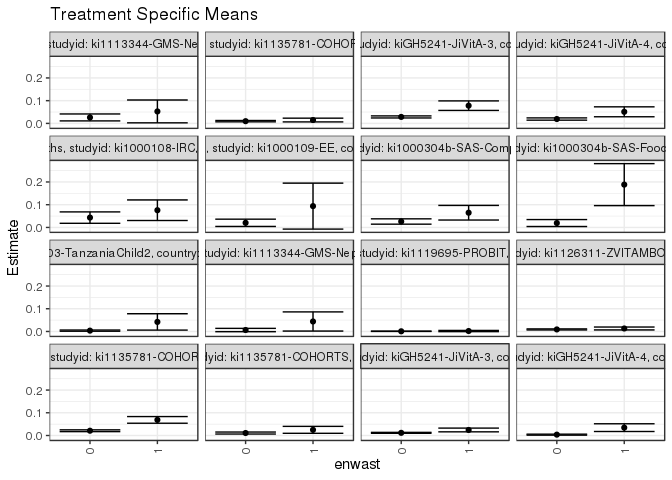

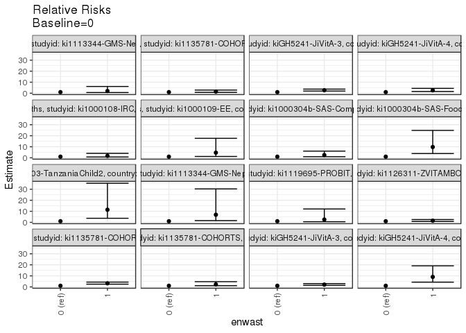

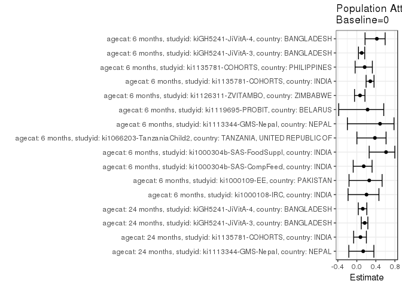

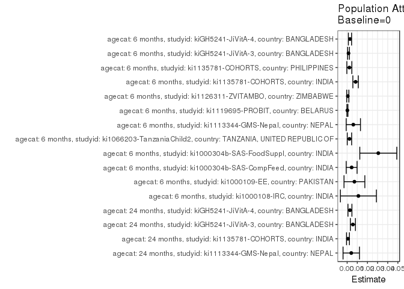

## Results Table

### Parameter: TSM

| agecat | studyid | country | intervention_level | baseline_level | estimate | ci_lower | ci_upper |
| --- | --- | --- | --- | --- | --- | --- | --- |
| 6 months | ki1000108-IRC | INDIA | 0 | NA | 0.0433071 | 0.0182425 | 0.0683717 |
| 6 months | ki1000108-IRC | INDIA | 1 | NA | 0.0757576 | 0.0305584 | 0.1209567 |
| 6 months | ki1000109-EE | PAKISTAN | 0 | NA | 0.0202703 | 0.0041917 | 0.0363489 |
| 6 months | ki1000109-EE | PAKISTAN | 1 | NA | 0.0937500 | -0.0073953 | 0.1948953 |
| 6 months | ki1000304b-SAS-CompFeed | INDIA | 0 | NA | 0.0261438 | 0.0143634 | 0.0379242 |
| 6 months | ki1000304b-SAS-CompFeed | INDIA | 1 | NA | 0.0647482 | 0.0325762 | 0.0969202 |
| 6 months | ki1000304b-SAS-FoodSuppl | INDIA | 0 | NA | 0.0192926 | 0.0039851 | 0.0346001 |
| 6 months | ki1000304b-SAS-FoodSuppl | INDIA | 1 | NA | 0.1884058 | 0.0960185 | 0.2807931 |
| 6 months | ki1066203-TanzaniaChild2 | TANZANIA, UNITED REPUBLIC OF | 0 | NA | 0.0036842 | 0.0009593 | 0.0064091 |
| 6 months | ki1066203-TanzaniaChild2 | TANZANIA, UNITED REPUBLIC OF | 1 | NA | 0.0420168 | 0.0059612 | 0.0780724 |
| 6 months | ki1113344-GMS-Nepal | NEPAL | 0 | NA | 0.0063830 | -0.0008232 | 0.0135892 |
| 6 months | ki1113344-GMS-Nepal | NEPAL | 1 | NA | 0.0439560 | 0.0017997 | 0.0861124 |
| 6 months | ki1119695-PROBIT | BELARUS | 0 | NA | 0.0007862 | 0.0002844 | 0.0012881 |
| 6 months | ki1119695-PROBIT | BELARUS | 1 | NA | 0.0019795 | -0.0006819 | 0.0046409 |
| 6 months | ki1126311-ZVITAMBO | ZIMBABWE | 0 | NA | 0.0089489 | 0.0066755 | 0.0112222 |
| 6 months | ki1126311-ZVITAMBO | ZIMBABWE | 1 | NA | 0.0131040 | 0.0067250 | 0.0194831 |
| 6 months | ki1135781-COHORTS | INDIA | 0 | NA | 0.0210821 | 0.0172359 | 0.0249283 |
| 6 months | ki1135781-COHORTS | INDIA | 1 | NA | 0.0687225 | 0.0540037 | 0.0834413 |
| 6 months | ki1135781-COHORTS | PHILIPPINES | 0 | NA | 0.0109639 | 0.0066008 | 0.0153270 |
| 6 months | ki1135781-COHORTS | PHILIPPINES | 1 | NA | 0.0249377 | 0.0096724 | 0.0402029 |
| 6 months | kiGH5241-JiVitA-3 | BANGLADESH | 0 | NA | 0.0117712 | 0.0096579 | 0.0138846 |
| 6 months | kiGH5241-JiVitA-3 | BANGLADESH | 1 | NA | 0.0243822 | 0.0160858 | 0.0326787 |
| 6 months | kiGH5241-JiVitA-4 | BANGLADESH | 0 | NA | 0.0038314 | 0.0016939 | 0.0059689 |
| 6 months | kiGH5241-JiVitA-4 | BANGLADESH | 1 | NA | 0.0346154 | 0.0175593 | 0.0516715 |
| 24 months | ki1113344-GMS-Nepal | NEPAL | 0 | NA | 0.0261905 | 0.0109018 | 0.0414792 |
| 24 months | ki1113344-GMS-Nepal | NEPAL | 1 | NA | 0.0526316 | 0.0023786 | 0.1028846 |
| 24 months | ki1135781-COHORTS | INDIA | 0 | NA | 0.0097364 | 0.0067704 | 0.0127024 |
| 24 months | ki1135781-COHORTS | INDIA | 1 | NA | 0.0147239 | 0.0064540 | 0.0229939 |
| 24 months | kiGH5241-JiVitA-3 | BANGLADESH | 0 | NA | 0.0284952 | 0.0239352 | 0.0330551 |
| 24 months | kiGH5241-JiVitA-3 | BANGLADESH | 1 | NA | 0.0780488 | 0.0570501 | 0.0990474 |
| 24 months | kiGH5241-JiVitA-4 | BANGLADESH | 0 | NA | 0.0192182 | 0.0142041 | 0.0242323 |
| 24 months | kiGH5241-JiVitA-4 | BANGLADESH | 1 | NA | 0.0510345 | 0.0292193 | 0.0728496 |

### Parameter: E(Y)

| agecat | studyid | country | intervention_level | baseline_level | estimate | ci_lower | ci_upper |
| --- | --- | --- | --- | --- | --- | --- | --- |
| 6 months | ki1000108-IRC | INDIA | NA | NA | 0.0544041 | 0.0317480 | 0.0770603 |
| 6 months | ki1000109-EE | PAKISTAN | NA | NA | 0.0274390 | 0.0097332 | 0.0451449 |
| 6 months | ki1000304b-SAS-CompFeed | INDIA | NA | NA | 0.0305785 | 0.0222921 | 0.0388649 |
| 6 months | ki1000304b-SAS-FoodSuppl | INDIA | NA | NA | 0.0500000 | 0.0280580 | 0.0719420 |
| 6 months | ki1066203-TanzaniaChild2 | TANZANIA, UNITED REPUBLIC OF | NA | NA | 0.0059435 | 0.0025899 | 0.0092972 |
| 6 months | ki1113344-GMS-Nepal | NEPAL | NA | NA | 0.0124777 | 0.0032839 | 0.0216715 |
| 6 months | ki1119695-PROBIT | BELARUS | NA | NA | 0.0010159 | 0.0004235 | 0.0016082 |
| 6 months | ki1126311-ZVITAMBO | ZIMBABWE | NA | NA | 0.0095982 | 0.0074362 | 0.0117601 |
| 6 months | ki1135781-COHORTS | INDIA | NA | NA | 0.0294072 | 0.0252982 | 0.0335163 |
| 6 months | ki1135781-COHORTS | PHILIPPINES | NA | NA | 0.0131274 | 0.0087431 | 0.0175117 |
| 6 months | kiGH5241-JiVitA-3 | BANGLADESH | NA | NA | 0.0131212 | 0.0109516 | 0.0152909 |
| 6 months | kiGH5241-JiVitA-4 | BANGLADESH | NA | NA | 0.0066202 | 0.0041469 | 0.0090935 |
| 24 months | ki1113344-GMS-Nepal | NEPAL | NA | NA | 0.0302419 | 0.0151557 | 0.0453282 |
| 24 months | ki1135781-COHORTS | INDIA | NA | NA | 0.0105452 | 0.0077209 | 0.0133694 |
| 24 months | kiGH5241-JiVitA-3 | BANGLADESH | NA | NA | 0.0341470 | 0.0294209 | 0.0388732 |
| 24 months | kiGH5241-JiVitA-4 | BANGLADESH | NA | NA | 0.0219728 | 0.0170964 | 0.0268491 |

### Parameter: RR

| agecat | studyid | country | intervention_level | baseline_level | estimate | ci_lower | ci_upper |
| --- | --- | --- | --- | --- | --- | --- | --- |
| 6 months | ki1000108-IRC | INDIA | 0 | 0 | 1.000000 | 1.0000000 | 1.000000 |
| 6 months | ki1000108-IRC | INDIA | 1 | 0 | 1.749311 | 0.7618527 | 4.016642 |
| 6 months | ki1000109-EE | PAKISTAN | 0 | 0 | 1.000000 | 1.0000000 | 1.000000 |
| 6 months | ki1000109-EE | PAKISTAN | 1 | 0 | 4.625000 | 1.2121338 | 17.647082 |
| 6 months | ki1000304b-SAS-CompFeed | INDIA | 0 | 0 | 1.000000 | 1.0000000 | 1.000000 |
| 6 months | ki1000304b-SAS-CompFeed | INDIA | 1 | 0 | 2.476619 | 1.0169935 | 6.031150 |
| 6 months | ki1000304b-SAS-FoodSuppl | INDIA | 0 | 0 | 1.000000 | 1.0000000 | 1.000000 |
| 6 months | ki1000304b-SAS-FoodSuppl | INDIA | 1 | 0 | 9.765700 | 3.8425498 | 24.819172 |
| 6 months | ki1066203-TanzaniaChild2 | TANZANIA, UNITED REPUBLIC OF | 0 | 0 | 1.000000 | 1.0000000 | 1.000000 |
| 6 months | ki1066203-TanzaniaChild2 | TANZANIA, UNITED REPUBLIC OF | 1 | 0 | 11.404562 | 3.6734787 | 35.406229 |
| 6 months | ki1113344-GMS-Nepal | NEPAL | 0 | 0 | 1.000000 | 1.0000000 | 1.000000 |
| 6 months | ki1113344-GMS-Nepal | NEPAL | 1 | 0 | 6.886446 | 1.5655118 | 30.292420 |
| 6 months | ki1119695-PROBIT | BELARUS | 0 | 0 | 1.000000 | 1.0000000 | 1.000000 |
| 6 months | ki1119695-PROBIT | BELARUS | 1 | 0 | 2.517783 | 0.5238295 | 12.101706 |
| 6 months | ki1126311-ZVITAMBO | ZIMBABWE | 0 | 0 | 1.000000 | 1.0000000 | 1.000000 |
| 6 months | ki1126311-ZVITAMBO | ZIMBABWE | 1 | 0 | 1.464318 | 0.8455990 | 2.535749 |
| 6 months | ki1135781-COHORTS | INDIA | 0 | 0 | 1.000000 | 1.0000000 | 1.000000 |
| 6 months | ki1135781-COHORTS | INDIA | 1 | 0 | 3.259756 | 2.4603564 | 4.318890 |
| 6 months | ki1135781-COHORTS | PHILIPPINES | 0 | 0 | 1.000000 | 1.0000000 | 1.000000 |
| 6 months | ki1135781-COHORTS | PHILIPPINES | 1 | 0 | 2.274522 | 1.0959791 | 4.720392 |
| 6 months | kiGH5241-JiVitA-3 | BANGLADESH | 0 | 0 | 1.000000 | 1.0000000 | 1.000000 |
| 6 months | kiGH5241-JiVitA-3 | BANGLADESH | 1 | 0 | 2.071342 | 1.4338745 | 2.992213 |
| 6 months | kiGH5241-JiVitA-4 | BANGLADESH | 0 | 0 | 1.000000 | 1.0000000 | 1.000000 |
| 6 months | kiGH5241-JiVitA-4 | BANGLADESH | 1 | 0 | 9.034615 | 4.2786035 | 19.077317 |
| 24 months | ki1113344-GMS-Nepal | NEPAL | 0 | 0 | 1.000000 | 1.0000000 | 1.000000 |
| 24 months | ki1113344-GMS-Nepal | NEPAL | 1 | 0 | 2.009569 | 0.6562615 | 6.153597 |
| 24 months | ki1135781-COHORTS | INDIA | 0 | 0 | 1.000000 | 1.0000000 | 1.000000 |
| 24 months | ki1135781-COHORTS | INDIA | 1 | 0 | 1.512255 | 0.7982295 | 2.864984 |
| 24 months | kiGH5241-JiVitA-3 | BANGLADESH | 0 | 0 | 1.000000 | 1.0000000 | 1.000000 |
| 24 months | kiGH5241-JiVitA-3 | BANGLADESH | 1 | 0 | 2.739018 | 2.0036225 | 3.744327 |
| 24 months | kiGH5241-JiVitA-4 | BANGLADESH | 0 | 0 | 1.000000 | 1.0000000 | 1.000000 |
| 24 months | kiGH5241-JiVitA-4 | BANGLADESH | 1 | 0 | 2.655529 | 1.5949768 | 4.421277 |

### Parameter: PAR

| agecat | studyid | country | intervention_level | baseline_level | estimate | ci_lower | ci_upper |
| --- | --- | --- | --- | --- | --- | --- | --- |
| 6 months | ki1000108-IRC | INDIA | 0 | NA | 0.0110971 | -0.0066439 | 0.0288380 |
| 6 months | ki1000109-EE | PAKISTAN | 0 | NA | 0.0071688 | -0.0030986 | 0.0174361 |
| 6 months | ki1000304b-SAS-CompFeed | INDIA | 0 | NA | 0.0044347 | -0.0009261 | 0.0097955 |
| 6 months | ki1000304b-SAS-FoodSuppl | INDIA | 0 | NA | 0.0307074 | 0.0124804 | 0.0489344 |
| 6 months | ki1066203-TanzaniaChild2 | TANZANIA, UNITED REPUBLIC OF | 0 | NA | 0.0022593 | 0.0000921 | 0.0044266 |
| 6 months | ki1113344-GMS-Nepal | NEPAL | 0 | NA | 0.0060947 | -0.0009369 | 0.0131263 |
| 6 months | ki1119695-PROBIT | BELARUS | 0 | NA | 0.0002296 | -0.0002931 | 0.0007524 |
| 6 months | ki1126311-ZVITAMBO | ZIMBABWE | 0 | NA | 0.0006493 | -0.0004094 | 0.0017080 |
| 6 months | ki1135781-COHORTS | INDIA | 0 | NA | 0.0083251 | 0.0056305 | 0.0110198 |
| 6 months | ki1135781-COHORTS | PHILIPPINES | 0 | NA | 0.0021635 | -0.0003023 | 0.0046293 |
| 6 months | kiGH5241-JiVitA-3 | BANGLADESH | 0 | NA | 0.0013500 | 0.0004592 | 0.0022409 |
| 6 months | kiGH5241-JiVitA-4 | BANGLADESH | 0 | NA | 0.0027888 | 0.0012122 | 0.0043653 |
| 24 months | ki1113344-GMS-Nepal | NEPAL | 0 | NA | 0.0040515 | -0.0040407 | 0.0121436 |
| 24 months | ki1135781-COHORTS | INDIA | 0 | NA | 0.0008088 | -0.0006168 | 0.0022343 |
| 24 months | kiGH5241-JiVitA-3 | BANGLADESH | 0 | NA | 0.0056518 | 0.0031511 | 0.0081526 |
| 24 months | kiGH5241-JiVitA-4 | BANGLADESH | 0 | NA | 0.0027546 | 0.0008093 | 0.0046999 |

### Parameter: PAF

| agecat | studyid | country | intervention_level | baseline_level | estimate | ci_lower | ci_upper |
| --- | --- | --- | --- | --- | --- | --- | --- |
| 6 months | ki1000108-IRC | INDIA | 0 | NA | 0.2039745 | -0.1837706 | 0.4647133 |
| 6 months | ki1000109-EE | PAKISTAN | 0 | NA | 0.2612613 | -0.1639114 | 0.5311199 |
| 6 months | ki1000304b-SAS-CompFeed | INDIA | 0 | NA | 0.1450274 | -0.0761584 | 0.3207522 |
| 6 months | ki1000304b-SAS-FoodSuppl | INDIA | 0 | NA | 0.6141479 | 0.2597375 | 0.7988797 |
| 6 months | ki1066203-TanzaniaChild2 | TANZANIA, UNITED REPUBLIC OF | 0 | NA | 0.3801316 | 0.0015864 | 0.6151526 |
| 6 months | ki1113344-GMS-Nepal | NEPAL | 0 | NA | 0.4884498 | -0.1985950 | 0.7816747 |
| 6 months | ki1119695-PROBIT | BELARUS | 0 | NA | 0.2260594 | -0.3805449 | 0.5661250 |
| 6 months | ki1126311-ZVITAMBO | ZIMBABWE | 0 | NA | 0.0676455 | -0.0482802 | 0.1707514 |
| 6 months | ki1135781-COHORTS | INDIA | 0 | NA | 0.2830986 | 0.1950310 | 0.3615312 |
| 6 months | ki1135781-COHORTS | PHILIPPINES | 0 | NA | 0.1648080 | -0.0357851 | 0.3265537 |
| 6 months | kiGH5241-JiVitA-3 | BANGLADESH | 0 | NA | 0.1028881 | 0.0350168 | 0.1659857 |
| 6 months | kiGH5241-JiVitA-4 | BANGLADESH | 0 | NA | 0.4212543 | 0.1728898 | 0.5950399 |
| 24 months | ki1113344-GMS-Nepal | NEPAL | 0 | NA | 0.1339683 | -0.1686908 | 0.3582469 |
| 24 months | ki1135781-COHORTS | INDIA | 0 | NA | 0.0766949 | -0.0671112 | 0.2011214 |
| 24 months | kiGH5241-JiVitA-3 | BANGLADESH | 0 | NA | 0.1655151 | 0.0934210 | 0.2318761 |
| 24 months | kiGH5241-JiVitA-4 | BANGLADESH | 0 | NA | 0.1253631 | 0.0312900 | 0.2103005 |